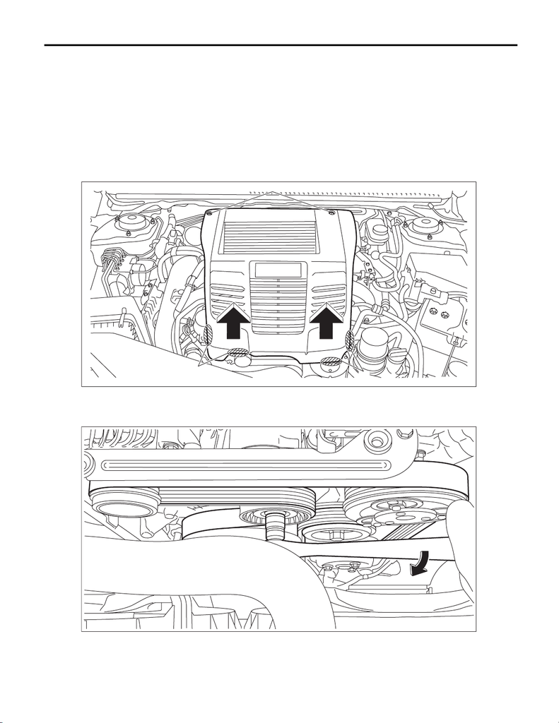

ME(w/o STI)-78

V-belt

MECHANICAL

12.V-belt

A: REMOVAL

NOTE:

When replacing a single part, perform the work with the engine assembly installed to body.

1. V-BELT

1) Remove the collector cover.

(1) Remove the clips (A).

(2) Hold the shaded area (B) by hand and carefully pull the RH side (C) upward.

(3) Hold the shaded area (D) by hand and carefully pull the LH side (E) upward.

2) Remove the air intake duct. <Ref. to IN(w/o STI)-22, REMOVAL, Air Intake Duct.>

3) Attach the tool to the V-belt tensioner assembly, and rotate the tool clockwise to loosen and remove the

V-belt.

EX-03204

(A)

(B)

(C)

(E)

(D)

ME-07919

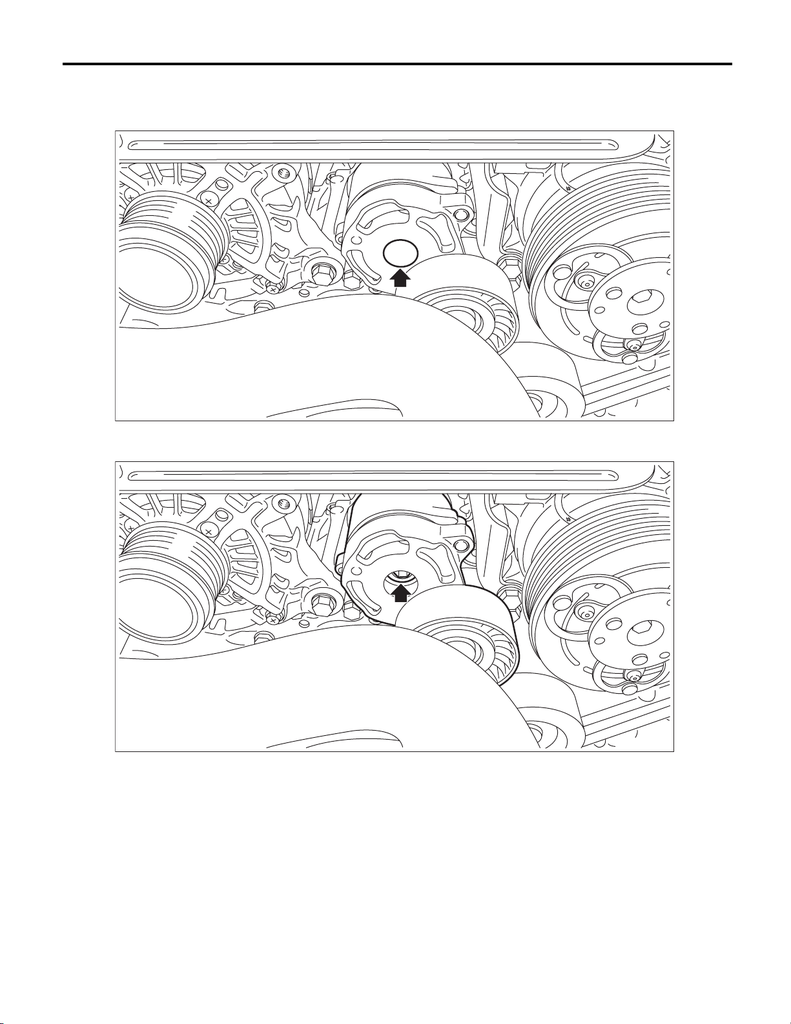

ME(w/o STI)-79

V-belt

MECHANICAL

2. V-BELT TENSIONER ASSEMBLY

1) Remove the V-belts. <Ref. to ME(w/o STI)-78, V-BELT, REMOVAL, V-belt.>

2) Remove the cap from V-belt tensioner assembly.

3) Remove the bolt securing the V-belt tensioner assembly to the generator bracket, and remove the V-belt

tensioner assembly.

ME-07920

ME-07921

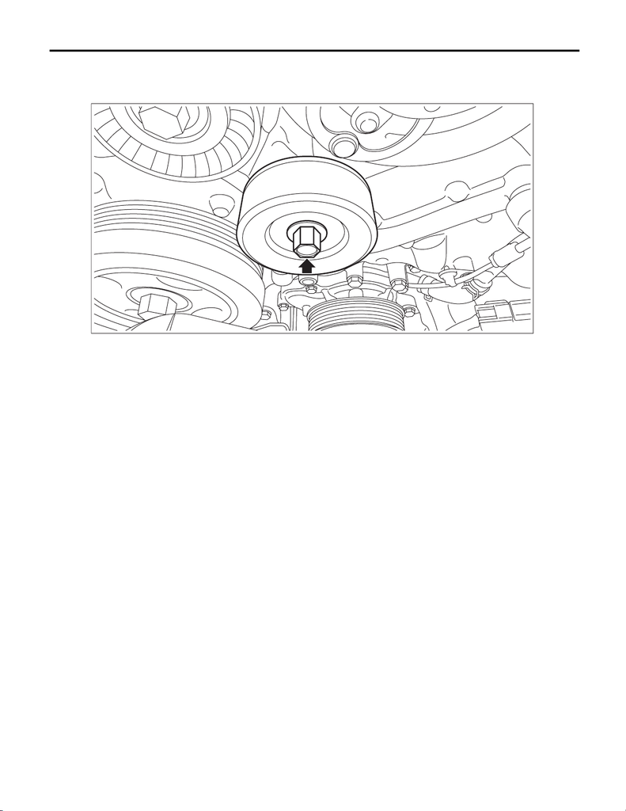

ME(w/o STI)-80

V-belt

MECHANICAL

3. IDLER PULLEY

1) Remove the V-belts. <Ref. to ME(w/o STI)-78, V-BELT, REMOVAL, V-belt.>

ME-07350

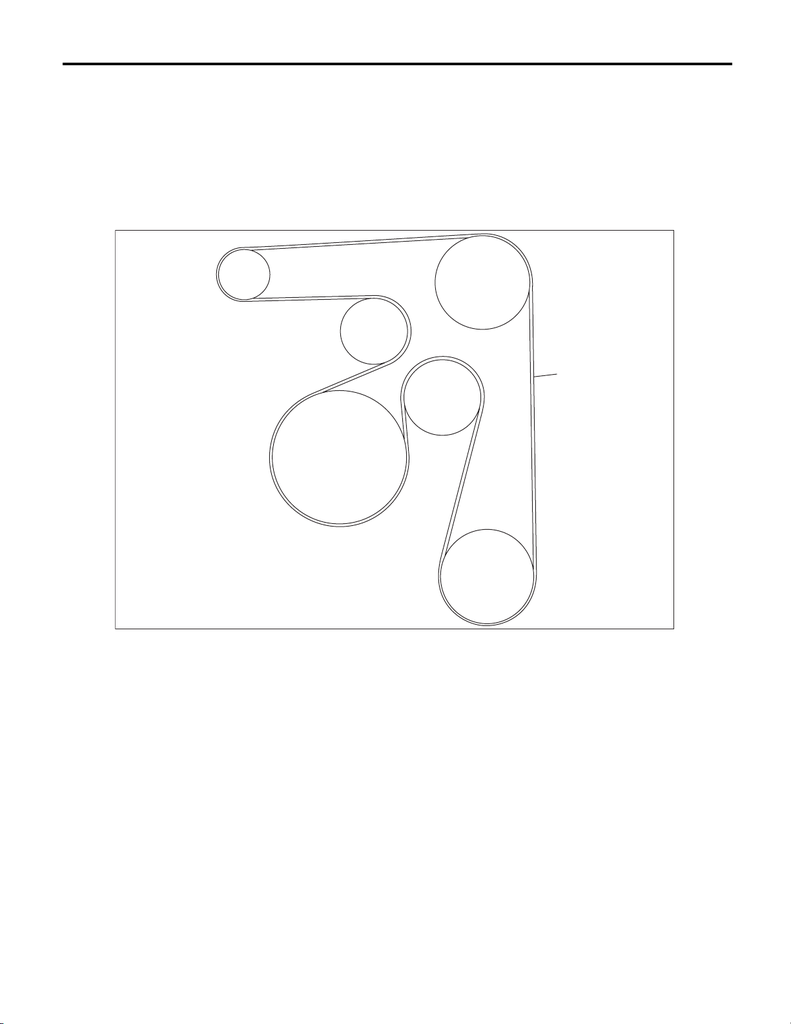

ME(w/o STI)-81

V-belt

MECHANICAL

B: INSTALLATION

1. V-BELT

Install in the reverse order of removal.

CAUTION:

• When reusing the V-belt, wipe off dust and water with cloth.

• Do not use the V-belt if there is any oil, grease or coolant on the belt.

• Be careful not to rub the V-belt end surface with bare hands; exposed core may cause injury.

• Wipe off any dust, oil and water on the groove of each pulley with cloth.

(A) V-belt (D) V-belt tensioner ASSY (G) A/C compressor pulley

(B) Water pump pulley (E) Generator pulley

(C) Crank pulley (F) Idler pulley

ME-06606

(C)

(B)

(D)

(F)

(G)

(E)

(A)

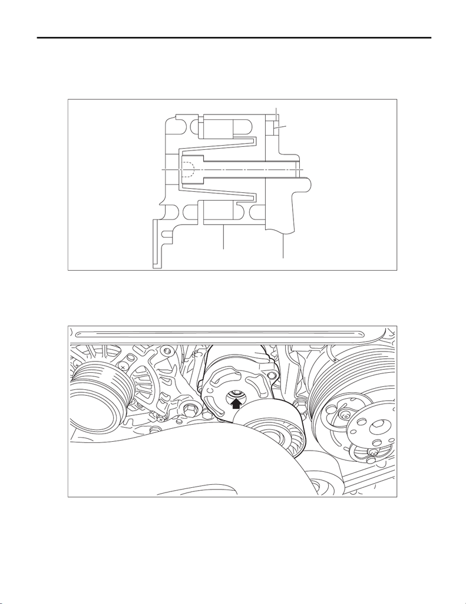

ME(w/o STI)-82

V-belt

MECHANICAL

2. V-BELT TENSIONER ASSEMBLY

Install in the reverse order of removal.

NOTE:

When installing the V-belt tensioner assembly, insert the protrusion of V-belt tensioner assembly into the hole

for preventing rotation at the generator bracket.

Tightening torque:

25 N·m (2.5 kgf-m, 18.4 ft-lb)

(A) V-belt tensioner ASSY (C) Hole to prevent rotation (D) Protrusion portion

(B) Generator bracket

ME-06608

(A)

(B)

(C)

(D)

ME-07921

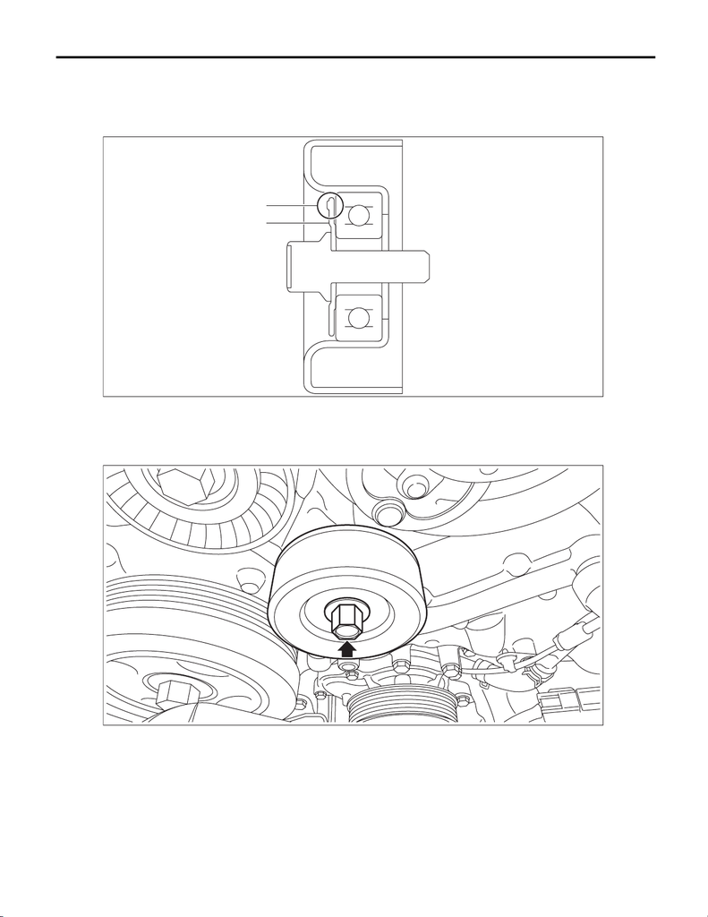

ME(w/o STI)-83

V-belt

MECHANICAL

3. IDLER PULLEY

Install in the reverse order of removal.

NOTE:

When installing the idler pulley, be careful of the idler pulley cover direction.

Tightening torque:

36 N·m (3.7 kgf-m, 26.6 ft-lb)

(a) Idler pulley cover (b) Protrusion (3 places)

ME-06607

(b)

(a)

ME-07350

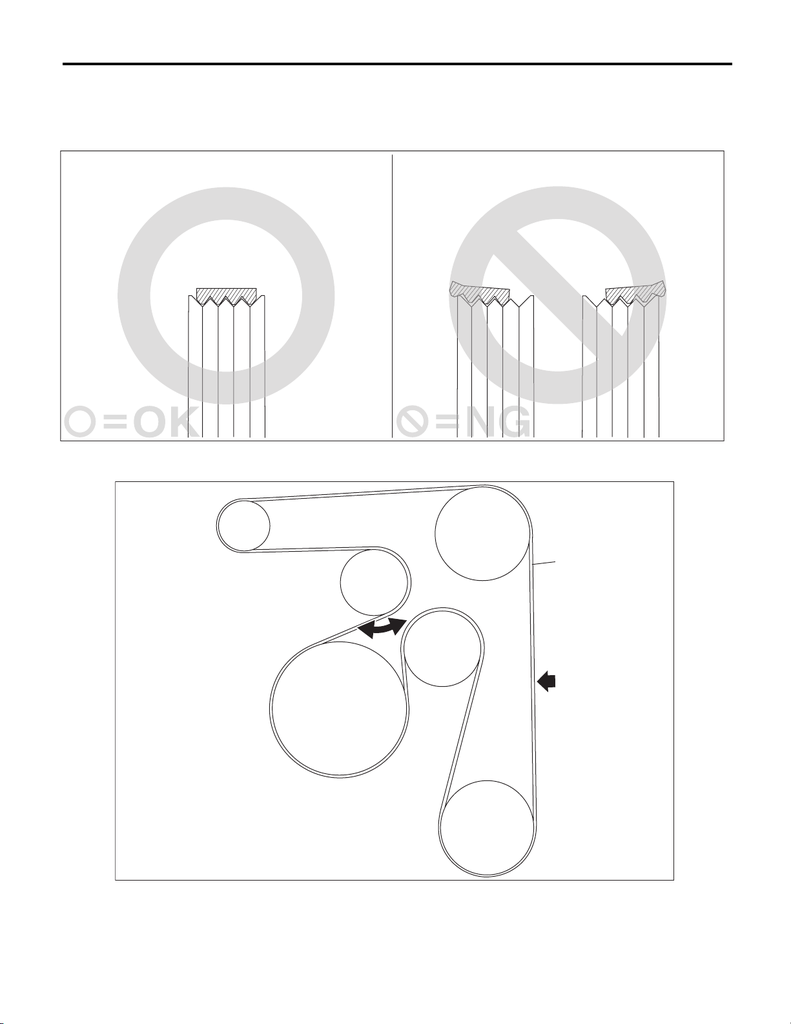

ME(w/o STI)-84

V-belt

MECHANICAL

C: INSPECTION

1) Check the V-belt for cracks, tear or wear.

2) Check the V-belt tensioner assembly and idler pulley for deformation, cracks or other damages.

3) Check that the V-belt ribs are securely placed on the rib grooves for each pulley.

4) Check that the V-belt tensioner assembly (C) moves in the direction of arrow (D), when the V-belt (A) is

pushed and released by the area indicated by the arrow (B).

5) Start the engine and confirm that the V-belt rotates smoothly and no abnormal noise is emitted.

ME-06064

ME-06609

(C)

(A)

(B)

(D)